# Pan-ALS vs control differential splicing

Dr Oliver Ziff The Francis Crick Institute Institute of Neurology University College London, UK

2022-07-12

# Fig 4 Splicing pan ALS

## Volcano

```r
majiq.als_vs_ctrl.RBP.junction_labels <- als_ctrl.voila %>% filter(changing_dpsi0.1 == TRUE, gene_name %in% c("YTHDC2", "THOC1", "PRR3", "STAU2", "PTBP3", "SREK1", "POLDIP3")) %>% group_by(gene_name) %>% top_n(2, wt = abs(deltapsi)) %>% pull(lsv_junction_id)
majiq.als_vs_ctrl.ALS.junction_labels <- als_ctrl.voila %>% filter(changing_dpsi0.1 == TRUE, gene_name %in% c(ALS_genes)) %>% group_by(gene_name) %>% top_n(2, wt = abs(deltapsi)) %>% pull(lsv_junction_id)
majiq.als_vs_ctrl.DDR.junction_labels <- als_ctrl.voila %>% filter(changing_dpsi0.1 == TRUE, gene_name %in% p53.DDR.repair_gene_set) %>% group_by(gene_name) %>% top_n(2, wt = abs(deltapsi)) %>% pull(lsv_junction_id)
majiq.als_vs_ctrl.extra_labels <- als_ctrl.voila %>% filter(changing_dpsi0.1 == TRUE, gene_name %in% c("METTL22","LINC00665")) %>% group_by(gene_name) %>% top_n(2, wt = abs(deltapsi)) %>% pull(lsv_junction_id)
majiq.als_vs_ctrl.volcano <- majiq_het_volcano_plot(als_ctrl.voila, "Alternative splicing: pan ALS", numerator = "ALS", denomenator = "CTRL", subtitle = "polyA: 43 CTRL vs 48 ALS", ymax = 5, xmax = 0.32, dpi = 300, junction_labels = c(majiq.als_vs_ctrl.RBP.junction_labels, majiq.als_vs_ctrl.ALS.junction_labels, majiq.als_vs_ctrl.DDR.junction_labels, majiq.als_vs_ctrl.extra_labels))
```

```
## # A tibble: 3 × 2
##   sig             n
##   <chr>       <int>
## 1 non_sig    137322
## 2 sig           227
## 3 sig_strong     37
```

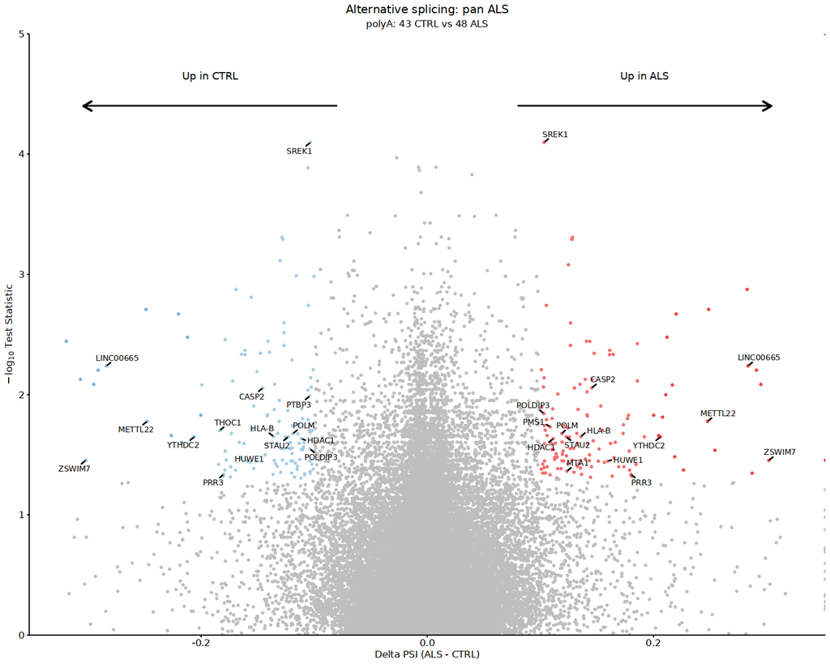

```r
majiq.als_vs_ctrl.volcano
```

## Functional enrichment terms

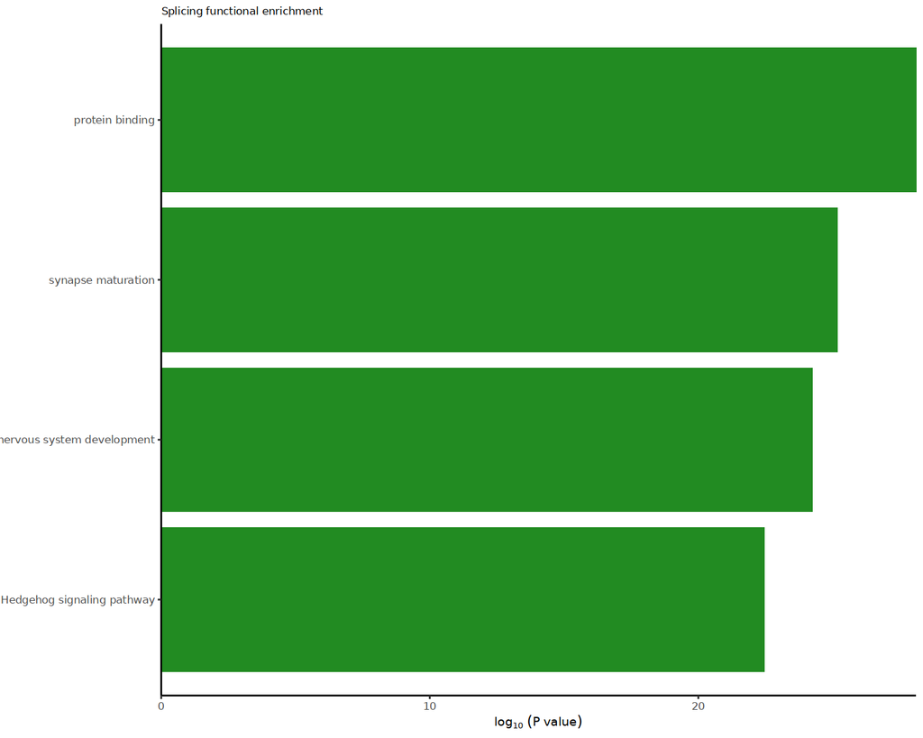

```r
als_ctrl.voila.gost = als_ctrl.voila %>% filter(changing_dpsi0.1 == TRUE) %>% distinct(gene_id) %>% pull(gene_id) %>% gost()
als_ctrl.voila.gost_filt <- als_ctrl.voila.gost$result %>% filter(!str_detect(source, "HPA|TF|CORUM")) %>% arrange( -log10(p_value) ) %>% mutate(query = "1")
majiq_als_go_list = c(
"Hedgehog signaling pathway",
"regulation of nervous system development",
"positive regulation of synapse maturation",
"protein binding")
als_ctrl.voila.gost_filt.terms <- als_ctrl.voila.gost_filt %>% filter(term_name %in% majiq_als_go_list)
als_ctrl.voila.gost_filt.terms$term_name = gsub("positive regulation of |regulation of ", "", als_ctrl.voila.gost_filt.terms$term_name)
als_ctrl.voila.gost_filt.terms.curated <- curated_profiles(als_ctrl.voila.gost_filt.terms, cols = c("forestgreen")) + labs(title = "Splicing functional enrichment") + theme(plot.title=element_text(size=8), strip.text.y.right = element_blank())
als_ctrl.voila.gost_filt.terms.curated
```

## Modulizer

Pie chart of differential event splicing types

```r
modulizer_simplfied.sig.summary = pan_als.voila_modulizer %>% filter(abs(als_ctrl_het_median_dpsi) > 0.1, als_ctrl_het_tnom < 0.05) %>% count(modulizer_simplified) %>% mutate(modulizer_simplified = gsub("_"," ",modulizer_simplified), modulizer_simplified = fct_reorder(modulizer_simplified, n, .desc = TRUE)) %>% arrange(desc(modulizer_simplified)) %>%
  mutate(pct = n/sum(n) *100, pct.label = case_when(pct > 8 ~ paste(as.character(n),"\n", as.character(round(pct,1)),"%"), TRUE ~ ""), ypos = cumsum(pct) - 0.5*pct) #%>% print
modulizer_simplfied.sig.summary %>% print
```

```
## # A tibble: 8 × 5
##   modulizer_simplified     n    pct pct.label         ypos
##   <fct>                <int>  <dbl> <chr>            <dbl>
## 1 alt3and5prime            1  0.249 ""               0.125
## 2 alt5prime               12  2.99  ""               1.75
## 3 alt3prime               31  7.73  ""               7.11
## 4 alternate first exon    36  8.98  "36 \n 9 %"     15.5
## 5 alternate last exon     39  9.73  "39 \n 9.7 %"   24.8
## 6 multi exon spanning     46 11.5   "46 \n 11.5 %"  35.4
## 7 intron retention        54 13.5   "54 \n 13.5 %"  47.9
## 8 skipped exon           182 45.4   "182 \n 45.4 %" 77.3
```

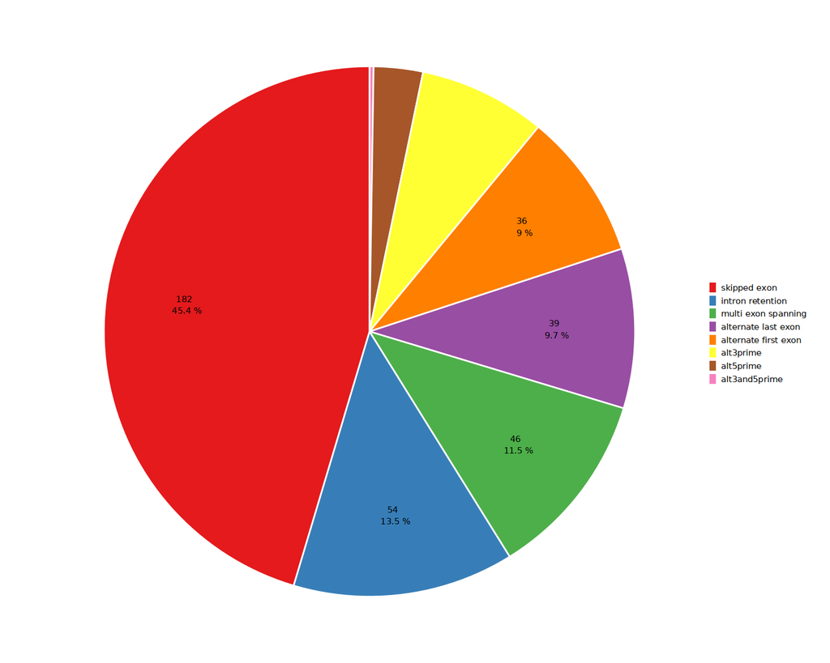

```r
pan_als.voila_modulizer.sig.pie = ggplot(modulizer_simplfied.sig.summary, aes(x = "", y = pct, fill = fct_reorder(modulizer_simplified, n, .desc = TRUE))) + geom_bar(width = 1, stat = "identity", color="white") + coord_polar("y", start=0) +
  geom_text(aes(x = 1.2, y = ypos, label = pct.label), color = "black", size=2.5) + scale_fill_brewer(palette="Set1") +
  theme_oz() + theme_void() + theme(legend.title=element_blank(), legend.position = "right", legend.text=element_text(size=7), legend.spacing.y = unit(1, 'mm'), legend.spacing.x = unit(1, 'mm'), legend.key.height = unit(0.4, 'cm'), legend.key.width = unit(0.3, 'cm')) + guides(fill=guide_legend(ncol=1))
pan_als.voila_modulizer.sig.pie
```

## Voila view

Imported violins from voila view

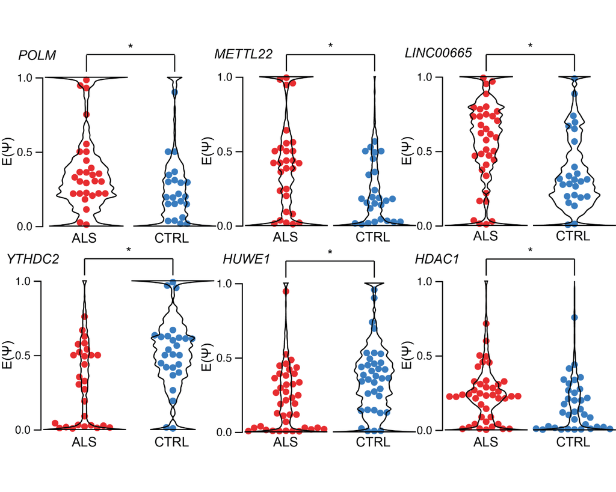

```r
polyA_majiq_violins_merged.png = magick::image_read(here(proj_path,"splicing/majiq/figures/polyA_majiq_violins_merged.png"))
polyA_majiq_violins_merged.gg = ggdraw() + draw_image(polyA_majiq_violins_merged.png)
polyA_majiq_violins_merged.gg
```

# Table S7 MAJIQ panALS datasets

```r
# als_ctrl.voila = read_voila_het(here(proj_path,"splicing/majiq_polyA/voila-tsv/als_vs_ctrl.tsv"), grp1 = "als", grp2 = "ctrl")
als_ctrl.voila.sig = als_ctrl.voila %>% filter(changing_dpsi0.1 == TRUE) %>% select(-contains("percentile"),-contains("changing"),-ucsc_lsv_link) %>% arrange(-abs(deltapsi))
kbl(als_ctrl.voila.sig) %>% kable_styling(bootstrap_options = c("striped", "hover", "condensed", "responsive"), fixed_thead = T) %>% scroll_box(width = "100%", height = "500px")
```

gene_name

gene_id

lsv_id

lsv_junction_id

junction_id

deltapsi

tnom

ttest

wilcoxon

als_median_psi

ctrl_median_psi

lsv_type

strand

seqid

als_num_quantified

ctrl_num_quantified

tnom_quantile

ttest_quantile

wilcoxon_quantile

tnom_score

num_junctions

num_exons

de_novo_junctions

junctions_coords

exons_coords

ir_coords

TVP23C-CDRT4

ENSG00000259024

ENSG00000259024:s:15545785-15545916

ENSG00000259024:s:15545785-15545916:j:15540561-15545785

ENSG00000259024:s:15545785-15545916_1

0.4599

0.0000062

0.0000091

0.0000545

0.9599

0.5000

s|1e1.1o1|1e2.1o1

17

33

30

0.002354

0.0003552

0.01004

15.0

2

3

0

15540561-15545785

15440208-15440285;15540433-15540561;15545785-15545916

NA

TVP23C-CDRT4

ENSG00000259024

ENSG00000259024:s:15545785-15545916

ENSG00000259024:s:15545785-15545916:j:15440285-15545785

ENSG00000259024:s:15545785-15545916_2

-0.4599

0.0000062

0.0000091

0.0000545

0.0401

0.5000

s|1e1.1o1|1e2.1o1

17

33

30

0.002354

0.0003251

0.01136

15.0

2

3

0

15440285-15545785

15440208-15440285;15540433-15540561;15545785-15545916

NA

SYNJ1

ENSG00000159082

ENSG00000159082:t:32673340-32673531

ENSG00000159082:t:32673340-32673531:j:32673531-32678645

ENSG00000159082:t:32673340-32673531_1

0.3225

0.0351600

0.0170500

0.0175800

0.4225

0.1000

t|1e1.1o1|1e2.1o1

21

31

25

0.465600

0.1763000

0.21250

19.0

2

3

0

32673531-32678645

32673340-32673531;32676332-32676355;32678645-32678810

NA

SYNJ1

ENSG00000159082

ENSG00000159082:t:32673340-32673531

ENSG00000159082:t:32673340-32673531:j:32673531-32676332

ENSG00000159082:t:32673340-32673531_2

-0.3225

0.0351600

0.0170500

0.0175800

0.5775

0.9000

t|1e1.1o1|1e2.1o1

21

31

25

0.465600

0.1832000

0.25840

19.0

2

3

0

32673531-32676332

32673340-32673531;32676332-32676355;32678645-32678810

NA

C2orf74

ENSG00000237651

ENSG00000237651:t:61162842-61162973

ENSG00000237651:t:61162842-61162973:j:61145196-61162842

ENSG00000237651:t:61162842-61162973_1

-0.3192

0.0035990

0.0028570

0.0047300

0.4764

0.7956

t|1e1.1o1|1e2.1o1|1e3.1o1|1e4.1o1

2

29

23

0.124200

0.0421300

0.04840

15.0

4

5

0

61145196-61162842

61145068-61145196;61157862-61158012;61159318-61159439;61162416-61162609;61162842-61162973

NA

AC004080.6

ENSG00000273433

ENSG00000273433:s:27140083-27140186

ENSG00000273433:s:27140083-27140186:j:27129572-27140082

ENSG00000273433:s:27140083-27140186_3

-0.3067

0.0074640

0.2299000

0.1349000

0.2646

0.5713

s|1e1.1o2|1e1.2o2|i

7

32

24

0.351200

0.5956000

0.67590

18.0

3

2

1

27129572-27140082

27128969-27129571;27140083-27140186

27129572-27140082

ZSWIM7

ENSG00000214941

ENSG00000214941:t:15976560-15977092

ENSG00000214941:t:15976560-15977092:j:15977092-15978044

ENSG00000214941:t:15976560-15977092_1

-0.3020

0.0352200

0.0712900

0.0265900

0.1390

0.4410

t|1e1.1o1|1e2.1o1

17

26

22

0.516000

0.3450000

0.35140

16.0

2

3

0

15977092-15978044

15976560-15977092;15977579-15977700;15977925-15978163

NA

ZSWIM7

ENSG00000214941

ENSG00000214941:t:15976560-15977092

ENSG00000214941:t:15976560-15977092:j:15977092-15977579

ENSG00000214941:t:15976560-15977092_2

0.3020

0.0352200

0.0712900

0.0265900

0.8610

0.5590

t|1e1.1o1|1e2.1o1

17

26

22

0.516000

0.3609000

0.30880

16.0

2

3

0

15977092-15977579

15976560-15977092;15977579-15977700;15977925-15978163

NA

SVIL

ENSG00000197321

ENSG00000197321:s:29529705-29529844

ENSG00000197321:s:29529705-29529844:j:29527056-29529705

ENSG00000197321:s:29529705-29529844_1

0.2949

0.0082270

0.0644500

0.0466300

0.5884

0.2935

s|1e1.1o1|1e2.1o1

10

35

28

0.294600

0.2797000

0.26760

20.0

2

3

0

29527056-29529705

29524472-29524715;29526961-29527056;29529705-29529844

NA

SVIL

ENSG00000197321

ENSG00000197321:s:29529705-29529844

ENSG00000197321:s:29529705-29529844:j:29524715-29529705

ENSG00000197321:s:29529705-29529844_2

-0.2949

0.0082270

0.0644500

0.0466300

0.4116

0.7065

s|1e1.1o1|1e2.1o1

10

35

28

0.167000

0.2342000

0.24500

20.0

2

3

0

29524715-29529705

29524472-29524715;29526961-29527056;29529705-29529844

NA

AGAP1

ENSG00000157985

ENSG00000157985:t:235968462-235968623

ENSG00000157985:t:235968462-235968623:j:235908906-235968462

ENSG00000157985:t:235968462-235968623_1

-0.2910

0.0062560

0.0026360

0.0037040

0.6733

0.9643

t|1e1.1o1|1e2.1o1

2

41

35

0.104300

0.1654000

0.05794

24.0

2

3

0

235908906-235968462

235908738-235908906;235930765-235930923;235968462-235968623

NA

AGAP1

ENSG00000157985

ENSG00000157985:t:235968462-235968623

ENSG00000157985:t:235968462-235968623:j:235930923-235968462

ENSG00000157985:t:235968462-235968623_2

0.2910

0.0062560

0.0026360

0.0036960

0.3267

0.0357

t|1e1.1o1|1e2.1o1

2

41

35

0.104300

0.1970000

0.06391

24.0

2

3

0

235930923-235968462

235908738-235908906;235930765-235930923;235968462-235968623

NA

AC004080.6

ENSG00000273433

ENSG00000273433:s:27140083-27140186

ENSG00000273433:s:27140083-27140186:j:27129571-27140083

ENSG00000273433:s:27140083-27140186_1

0.2872

0.0450000

0.2398000

0.1841000

0.6520

0.3648

s|1e1.1o2|1e1.2o2|i

7

32

24

0.569700

0.6136000

0.60480

18.5

3

2

1

27129571-27140083

27128969-27129571;27140083-27140186

27129572-27140082

LINC00665

ENSG00000232677

ENSG00000232677:t:36321993-36322030

ENSG00000232677:t:36321993-36322030:j:36322030-36322130

ENSG00000232677:t:36321993-36322030_2

0.2836

0.0057640

0.0231900

0.0156300

0.5913

0.3077

t|1e1.1o1|1e2.1o1

19

35

25

0.167400

0.1025000

0.09640

17.0

2

3

0

36322030-36322130

36321993-36322030;36322130-36322384;36328694-36330492

NA

LINC00665

ENSG00000232677

ENSG00000232677:t:36321993-36322030

ENSG00000232677:t:36321993-36322030:j:36322030-36330253

ENSG00000232677:t:36321993-36322030_1

-0.2836

0.0057640

0.0231900

0.0156300

0.4087

0.6923

t|1e1.1o1|1e2.1o1

19

35

25

0.160500

0.0786300

0.08196

17.0

2

3

0

36322030-36330253

36321993-36322030;36322130-36322384;36328694-36330492

NA

TVP23C

ENSG00000175106

ENSG00000175106:s:15545785-15545916

ENSG00000175106:s:15545785-15545916:j:15540561-15545785

ENSG00000175106:s:15545785-15545916_1

0.2828

0.0013340

0.0034140

0.0058790

0.8889

0.6061

s|1e1.1o1|1e2.1o1|1e3.1o1

17

33

29

0.044920

0.0305200

0.07798

18.0

3

4

0

15540561-15545785

15502264-15503232;15516419-15516659;15540433-15540561;15545785-15545916

NA

HSD11B1L

ENSG00000167733

ENSG00000167733:s:5684781-5684905

ENSG00000167733:s:5684781-5684905:j:5684905-5684989

ENSG00000167733:s:5684781-5684905_1

0.2543

0.0290100

0.0448100

0.0510500

0.6861

0.4318

s|1e1.2o3|1e1.3o3|1e2.1o1|1e3.1o1|1e4.1o1

19

35

33

0.315300

0.2743000

0.33330

23.0

5

5

0

5684905-5684989

5684781-5684905;5684965-5685119;5686416-5686527;5686900-5686991;5687282-5687308

NA

SUZ12P1

ENSG00000264538

ENSG00000264538:t:30743301-30743369

ENSG00000264538:t:30743301-30743369:j:30709811-30743301

ENSG00000264538:t:30743301-30743369_1

0.2487

0.0019550

0.1220000

0.0347700

0.4761

0.2274

t|1e1.1o1|1e2.1o1

17

34

32

0.298300

0.4982000

0.34630

22.0

2

3

0

30709811-30743301

30709299-30709811;30735033-30735097;30743301-30743369

NA

SUZ12P1

ENSG00000264538

ENSG00000264538:t:30743301-30743369

ENSG00000264538:t:30743301-30743369:j:30735097-30743301

ENSG00000264538:t:30743301-30743369_2

-0.2487

0.0019550

0.1220000

0.0348100

0.5239

0.7726

t|1e1.1o1|1e2.1o1

17

34

32

0.465400

0.5397000

0.27920

23.0

2

3

0

30735097-30743301

30709299-30709811;30735033-30735097;30743301-30743369

NA

METTL22

ENSG00000067365

ENSG00000067365:s:8644437-8645044

ENSG00000067365:s:8644437-8645044:j:8644725-8645908

ENSG00000067365:s:8644437-8645044_1

0.2478

0.0167100

0.0054820

0.0186900

0.4207

0.1729

s|1e1.1o1|1e2.1o1

16

29

26

0.282400

0.0650900

0.16580

17.0

2

3

0

8644725-8645908

8644437-8645044;8645908-8646027;8646108-8649654

NA

METTL22

ENSG00000067365

ENSG00000067365:s:8644437-8645044

ENSG00000067365:s:8644437-8645044:j:8644725-8646108

ENSG00000067365:s:8644437-8645044_2

-0.2478

0.0167100

0.0054820

0.0186900

0.5793

0.8271

s|1e1.1o1|1e2.1o1

16

29

26

0.282400

0.0540600

0.15050

17.0

2

3

0

8644725-8646108

8644437-8645044;8645908-8646027;8646108-8649654

NA

LINC02210

ENSG00000204650

ENSG00000204650:t:45645671-45655156

ENSG00000204650:t:45645671-45655156:j:45642304-45645670

ENSG00000204650:t:45645671-45655156_5

0.2265

0.0423800

0.0600400

0.0828300

0.4838

0.2573

t|1e1.1o1|1e2.1o1|1e3.1o1|1e4.1o1|i

17

24

23

0.554700

0.3447000

0.35790

15.0

5

5

1

45642304-45645670

45629904-45630456;45637201-45637959;45638975-45639520;45640362-45642303;45645671-45655156

45642304-45645670

P4HA2

ENSG00000072682

ENSG00000072682:t:132218545-132218668

ENSG00000072682:t:132218545-132218668:j:132218644-132227790

ENSG00000072682:t:132218545-132218668_4

-0.2263

0.0219000

0.0308500

0.0226200

0.4562

0.6825

t|1e4.1o3|2e1.1o1|2e2.1o1|2e3.1o2|2e4.1o3|2e4.2o3|2e4.3o3|2e5.1o1

5

29

30

0.302300

0.3612000

0.24840

19.0

8

6

0

132218644-132227790

132218545-132218668;132222045-132222091;132226697-132227378;132227539-132228082;132277209-132277600;132295178-132295315

NA

PLEC

ENSG00000178209

ENSG00000178209:s:143938151-143938240

ENSG00000178209:s:143938151-143938240:j:143937784-143938151

ENSG00000178209:s:143938151-143938240_1

0.2200

0.0021380

0.0176700

0.0017960

0.2898

0.0698

s|1e1.1o1|1e2.1o1

8

35

31

0.056870

0.1271000

0.04396

19.0

2

3

0

143937784-143938151

143937165-143937242;143937664-143937784;143938151-143938240

NA

PLEC

ENSG00000178209

ENSG00000178209:s:143938151-143938240

ENSG00000178209:s:143938151-143938240:j:143937242-143938151

ENSG00000178209:s:143938151-143938240_2

-0.2200

0.0021380

0.0176700

0.0017960

0.7102

0.9302

s|1e1.1o1|1e2.1o1

8

35

31

0.056870

0.1157000

0.03300

19.0

2

3

0

143937242-143938151

143937165-143937242;143937664-143937784;143938151-143938240

NA

ITPRID2

ENSG00000138434

ENSG00000138434:s:181916600-181917005

ENSG00000138434:s:181916600-181917005:j:181917006-181918322

ENSG00000138434:s:181916600-181917005_3

0.2188

0.0329000

0.0010500

0.0045880

0.2426

0.0238

s|1e1.1o1|1e2.1o1|i

2

38

29

0.243700

0.0561000

0.06979

22.0

3

3

0

181917006-181918322

181916600-181917005;181918323-181918470;181918598-181918675

181917006-181918322

CFLAR

ENSG00000003402

ENSG00000003402:s:201140186-201140735

ENSG00000003402:s:201140186-201140735:j:201140439-201141374

ENSG00000003402:s:201140186-201140735_1

-0.2173

0.0250700

0.0460500

0.0350500

0.3239

0.5412

s|1e1.1o1|1e2.1o1|1e3.1o1|1e4.1o2|1e5.1o1

2

29

25

0.376700

0.2474000

0.23340

18.0

5

6

0

201140439-201141374

201140186-201140735;201141374-201141602;201142645-201142762;201145378-201145432;201148951-201149052;201149754-201150355

NA

ECPAS

ENSG00000136813

ENSG00000136813:t:111451425-111451555

ENSG00000136813:t:111451425-111451555:j:111451555-111484116

ENSG00000136813:t:111451425-111451555_1

0.2167

0.0083090

0.0157000

0.0178100

0.4832

0.2665

t|1e1.1o1|1e2.1o1|1e3.1o1|1e4.1o1

9

25

24

0.205500

0.1446000

0.17220

15.0

4

5

0

111451555-111484116

111451425-111451555;111472897-111473000;111483504-111483679;111483985-111484057;111484116-111484261

NA

WDR27

ENSG00000184465

ENSG00000184465:t:169662304-169662424

ENSG00000184465:t:169662304-169662424:j:169662424-169664166

ENSG00000184465:t:169662304-169662424_1

-0.2120

0.0033300

0.0090750

0.0031400

0.1267

0.3387

t|1e1.1o1|1e2.1o1

6

35

26

0.352700

0.2194000

0.17570

19.0

2

3

0

169662424-169664166

169662304-169662424;169663563-169663878;169664166-169664632

NA

WDR27

ENSG00000184465

ENSG00000184465:t:169662304-169662424

ENSG00000184465:t:169662304-169662424:j:169662424-169663563

ENSG00000184465:t:169662304-169662424_2

0.2120

0.0033300

0.0090750

0.0031400

0.8733

0.6613

t|1e1.1o1|1e2.1o1

6

35

26

0.352700

0.1924000

0.12840

19.0

2

3

0

169662424-169663563

169662304-169662424;169663563-169663878;169664166-169664632

NA

C2orf74

ENSG00000237651

ENSG00000237651:t:61162842-61162973

ENSG00000237651:t:61162842-61162973:j:61158012-61162842

ENSG00000237651:t:61162842-61162973_2

0.2109

0.0100300

0.0308900

0.0067870

0.2407

0.0298

t|1e1.1o1|1e2.1o1|1e3.1o1|1e4.1o1

2

29

23

0.240100

0.2348000

0.12290

14.5

4

5

0

61158012-61162842

61145068-61145196;61157862-61158012;61159318-61159439;61162416-61162609;61162842-61162973

NA

ZSCAN29

ENSG00000140265

ENSG00000140265:t:43366110-43366808

ENSG00000140265:t:43366110-43366808:j:43366808-43368923

ENSG00000140265:t:43366110-43366808_2

0.2080

0.0153900

0.0025270

0.0011040

0.7430

0.5350

t|1e1.1o1|1e2.1o1|2e2.1o1|i

15

33

24

0.175600

0.0680300

0.06181

17.0

4

3

0

43366808-43368923

43366110-43366808;43368923-43369127;43369596-43369602

43366809-43368922

YTHDC2

ENSG00000047188

ENSG00000047188:t:113532879-113533045

ENSG00000047188:t:113532879-113533045:j:113515362-113532879

ENSG00000047188:t:113532879-113533045_1

0.2061

0.0224700

0.0022990

0.0067600

0.6852

0.4791

t|1e1.1o1|1e2.1o1

5

28

26

0.340500

0.0817400

0.06794

17.0

2

3

0

113515362-113532879

113515272-113515362;113526586-113526785;113532879-113533045

NA

YTHDC2

ENSG00000047188

ENSG00000047188:t:113532879-113533045

ENSG00000047188:t:113532879-113533045:j:113526785-113532879

ENSG00000047188:t:113532879-113533045_2

-0.2061

0.0224700

0.0022990

0.0067600

0.3148

0.5209

t|1e1.1o1|1e2.1o1

5

28

26

0.195400

0.0650700

0.08202

17.0

2

3

0

113526785-113532879

113515272-113515362;113526586-113526785;113532879-113533045

NA

P4HA2

ENSG00000072682

ENSG00000072682:t:132218545-132218668

ENSG00000072682:t:132218545-132218668:j:132218644-132227086

ENSG00000072682:t:132218545-132218668_5

0.2045

0.0219000

0.0294500

0.0168600

0.4680

0.2635

t|1e4.1o3|2e1.1o1|2e2.1o1|2e3.1o2|2e4.1o3|2e4.2o3|2e4.3o3|2e5.1o1

5

29

30

0.481200

0.4144000

0.27640

20.0

8

6

0

132218644-132227086

132218545-132218668;132222045-132222091;132226697-132227378;132227539-132228082;132277209-132277600;132295178-132295315

NA

GOLGA6L9

ENSG00000197978

ENSG00000197978:t:82432817-82432897

ENSG00000197978:t:82432817-82432897:j:82431949-82432817

ENSG00000197978:t:82432817-82432897_1

-0.2002

0.0148400

0.0256300

0.0222600

0.5212

0.7214

t|1e1.1o1|1e2.1o1

15

25

25

0.285000

0.1171000

0.12630

15.0

2

3

1

82431949-82432817

82431830-82432217;82432572-82432631;82432817-82432897

NA

GOLGA6L9

ENSG00000197978

ENSG00000197978:t:82432817-82432897

ENSG00000197978:t:82432817-82432897:j:82432631-82432817

ENSG00000197978:t:82432817-82432897_2

0.2002

0.0148400

0.0256300

0.0222600

0.4788

0.2786

t|1e1.1o1|1e2.1o1

15

25

25

0.285000

0.1071000

0.11280

15.0

2

3

0

82432631-82432817

82431830-82432217;82432572-82432631;82432817-82432897

NA

ECPAS

ENSG00000136813

ENSG00000136813:t:111451425-111451555

ENSG00000136813:t:111451425-111451555:j:111451555-111472897

ENSG00000136813:t:111451425-111451555_4

-0.1994

0.0083090

0.0235900

0.0125800

0.2319

0.4313

t|1e1.1o1|1e2.1o1|1e3.1o1|1e4.1o1

9

25

24

0.213400

0.1591000

0.14880

15.0

4

5

0

111451555-111472897

111451425-111451555;111472897-111473000;111483504-111483679;111483985-111484057;111484116-111484261

NA

TRAPPC5

ENSG00000181029

ENSG00000181029:t:7682242-7682322

ENSG00000181029:t:7682242-7682322:j:7681026-7682242

ENSG00000181029:t:7682242-7682322_2

0.1919

0.0224700

0.0071780

0.0134500

0.2760

0.0841

t|1e1.1o1|1e2.1o2|1e2.2o2

19

28

26

0.541400

0.2884000

0.33080

19.0

3

3

0

7681026-7682242

7680833-7680878;7680879-7681049;7682242-7682322

NA

TAF1C

ENSG00000103168

ENSG00000103168:t:84180170-84180344

ENSG00000103168:t:84180170-84180344:j:84180345-84180867

ENSG00000103168:t:84180170-84180344_3

0.1857

0.0076910

0.0453500

0.0231600

0.5349

0.3492

t|1e1.1o1|1e2.1o1|i

16

37

33

0.222300

0.2480000

0.18780

23.0

3

3

0

84180345-84180867

84180170-84180344;84180868-84180995;84181043-84181186

84180345-84180867

KIF1B

ENSG00000054523

ENSG00000054523:s:10277986-10278128

ENSG00000054523:s:10277986-10278128:j:10278128-10282322

ENSG00000054523:s:10277986-10278128_2

0.1857

0.0037700

0.2070000

0.1250000

0.4635

0.2778

s|1e1.1o1|1e2.1o1|1e3.1o1

1

43

37

0.328300

0.4082000

0.34510

27.0

3

4

0

10278128-10282322

10277986-10278128;10278558-10279138;10282322-10282383;10282400-10282533

NA

HOOK3

ENSG00000168172

ENSG00000168172:s:42997550-42998156

ENSG00000168172:s:42997550-42998156:j:42997637-43000271

ENSG00000168172:s:42997550-42998156_1

0.1846

0.0381000

0.0296700

0.0277500

0.9290

0.7444

s|1e1.1o1|1e2.1o1

8

29

24

0.500200

0.4375000

0.38050

17.0

2

3

0

42997637-43000271

42997550-42998156;43000271-43000276;43002107-43002141

NA

HOOK3

ENSG00000168172

ENSG00000168172:s:42997550-42998156

ENSG00000168172:s:42997550-42998156:j:42997637-43002107

ENSG00000168172:s:42997550-42998156_2

-0.1846

0.0381000

0.0296700

0.0277500

0.0710

0.2556

s|1e1.1o1|1e2.1o1

8

29

24

0.500200

0.4424000

0.36050

17.0

2

3

0

42997637-43002107

42997550-42998156;43000271-43000276;43002107-43002141

NA

THOC1

ENSG00000079134

ENSG00000079134:s:263493-264092

ENSG00000079134:s:263493-264092:j:260304-264026

ENSG00000079134:s:263493-264092_2

-0.1835

0.0199000

0.1028000

0.0919100

0.6455

0.8290

s|1e1.1o1|1e2.1o1|i

18

30

27

0.486900

0.8820000

0.64150

19.0

3

3

0

260304-264026

260186-260304;260718-261162;263493-264092

261163-263492

PPFIBP1

ENSG00000110841

ENSG00000110841:s:27656616-27657123

ENSG00000110841:s:27656616-27657123:j:27656730-27658816

ENSG00000110841:s:27656616-27657123_1

-0.1804

0.0476200

0.1222000

0.0801100

0.4986

0.6790

s|1e1.1o1|1e2.1o1

12

30

23

0.828900

0.5810000

0.52960

18.0

2

3

0

27656730-27658816

27656616-27657123;27658816-27658848;27660884-27660945

NA

PPFIBP1

ENSG00000110841

ENSG00000110841:s:27656616-27657123

ENSG00000110841:s:27656616-27657123:j:27656730-27660884

ENSG00000110841:s:27656616-27657123_2

0.1804

0.0476200

0.1222000

0.0801100

0.5014

0.3210

s|1e1.1o1|1e2.1o1

12

30

23

0.836000

0.5560000

0.51740

18.0

2

3

0

27656730-27660884

27656616-27657123;27658816-27658848;27660884-27660945

NA

PRR3

ENSG00000204576

ENSG00000204576:s:30558150-30558436

ENSG00000204576:s:30558150-30558436:j:30558212-30561328

ENSG00000204576:s:30558150-30558436_1

0.1800

0.0460600

0.3617000

0.1775000

0.4087

0.2287

s|1e1.1o1|1e2.1o1

6

25

22

0.830000

0.7574000

0.74420

16.0

2

3

0

30558212-30561328

30558150-30558436;30560031-30561508;30561834-30562124

NA

PRR3

ENSG00000204576

ENSG00000204576:s:30558150-30558436

ENSG00000204576:s:30558150-30558436:j:30558212-30561834

ENSG00000204576:s:30558150-30558436_2

-0.1800

0.0460600

0.3617000

0.1775000

0.5913

0.7713

s|1e1.1o1|1e2.1o1

6

25

22

0.830000

0.7720000

0.72750

16.0

2

3

0

30558212-30561834

30558150-30558436;30560031-30561508;30561834-30562124

NA

GIT1

ENSG00000108262

ENSG00000108262:t:29578731-29578779

ENSG00000108262:t:29578731-29578779:j:29578779-29578962

ENSG00000108262:t:29578731-29578779_2

-0.1789

0.0424400

0.3006000

0.1537000

0.6525

0.8314

t|1e1.1o1|1e2.1o1

17

45

41

0.487700

0.6695000

0.41640

32.0

2

3

0

29578779-29578962

29578731-29578779;29578962-29579330;29581047-29581479

NA

GIT1

ENSG00000108262

ENSG00000108262:t:29578731-29578779

ENSG00000108262:t:29578731-29578779:j:29578779-29581338

ENSG00000108262:t:29578731-29578779_1

0.1789

0.0424400

0.3006000

0.1537000

0.3475

0.1686

t|1e1.1o1|1e2.1o1

17

45

41

0.487700

0.7031000

0.47490

32.0

2

3

0

29578779-29581338

29578731-29578779;29578962-29579330;29581047-29581479

NA

MRPL33

ENSG00000243147

ENSG00000243147:t:27779433-27779734

ENSG00000243147:t:27779433-27779734:j:27772692-27779433

ENSG00000243147:t:27779433-27779734_1

-0.1787

0.0034900

0.0060950

0.0079410

0.4333

0.6120

t|1e1.1o1|1e2.1o1|i

2

45

40

0.173200

0.0522400

0.07774

30.0

3

3

0

27772692-27779433

27772674-27772855;27774424-27774530;27779433-27779734

27774531-27779432

RELCH

ENSG00000134444

ENSG00000134444:t:62221219-62221274

ENSG00000134444:t:62221219-62221274:j:62211242-62221219

ENSG00000134444:t:62221219-62221274_1

-0.1786

0.0294900

0.0443600

0.0241000

0.2697

0.4483

t|1e1.1o1|1e2.1o1

18

30

26

0.829200

0.5504000

0.39130

20.0

2

3

1

62211242-62221219

62211153-62211242;62220860-62221108;62221219-62221274

NA

RELCH

ENSG00000134444

ENSG00000134444:t:62221219-62221274

ENSG00000134444:t:62221219-62221274:j:62221108-62221219

ENSG00000134444:t:62221219-62221274_2

0.1786

0.0294900

0.0443600

0.0241000

0.7303

0.5517

t|1e1.1o1|1e2.1o1

18

30

26

0.611900

0.4907000

0.50990

19.0

2

3

0

62221108-62221219

62211153-62211242;62220860-62221108;62221219-62221274

NA

ZNF232

ENSG00000167840

ENSG00000167840:s:5111800-5112351

ENSG00000167840:s:5111800-5112351:j:5109868-5111800

ENSG00000167840:s:5111800-5112351_2

0.1779

0.0148400

0.0102200

0.0039720

0.5112

0.3333

s|1e1.1o1|1e2.1o2|1e2.2o2

17

25

25

0.710200

0.3119000

0.35640

16.0

3

3

0

5109868-5111800

5109394-5109868;5111076-5111219;5111800-5112351

NA

HOXC4

ENSG00000198353

ENSG00000198353:t:54053160-54053424

ENSG00000198353:t:54053160-54053424:j:54038014-54053160

ENSG00000198353:t:54053160-54053424_2

-0.1778

0.0349800

0.0129400

0.0135900

0.4955

0.6733

t|1e1.1o1|1e2.1o1|1e3.1o1|i

12

41

31

0.244400

0.1629000

0.13330

24.0

4

4

1

54038014-54053160

54016931-54017414;54037854-54038014;54047769-54047917;54053160-54053424

54047918-54053159

MRPL33

ENSG00000243147

ENSG00000243147:t:27779433-27779734

ENSG00000243147:t:27779433-27779734:j:27774530-27779433

ENSG00000243147:t:27779433-27779734_2

0.1770

0.0158000

0.0219600

0.0185100

0.5575

0.3805

t|1e1.1o1|1e2.1o1|i

2

45

40

0.418200

0.0867000

0.11640

31.0

3

3

0

27774530-27779433

27772674-27772855;27774424-27774530;27779433-27779734

27774531-27779432

RAPGEF1

ENSG00000107263

ENSG00000107263:s:131621796-131621998

ENSG00000107263:s:131621796-131621998:j:131602149-131621796

ENSG00000107263:s:131621796-131621998_4

-0.1741

0.0484300

0.0496900

0.0358800

0.4423

0.6164

s|1e1.1o2|1e1.2o2|1e2.1o1|1e3.1o1

9

36

29

0.186900

0.1216000

0.11820

22.0

4

4

0

131602149-131621796

131602061-131602149;131603961-131604053;131619051-131619209;131621796-131621998

NA

HERC4

ENSG00000148634

ENSG00000148634:t:67956878-67956976

ENSG00000148634:t:67956878-67956976:j:67956976-67959113

ENSG00000148634:t:67956878-67956976_2

0.1738

0.0398200

0.0893400

0.0526300

0.5000

0.3262

t|1e1.1o1|1e2.1o1

10

37

29

0.449100

0.3775000

0.34630

23.0

2

3

0

67956976-67959113

67956878-67956976;67959113-67959136;67964792-67966802

NA

HERC4

ENSG00000148634

ENSG00000148634:t:67956878-67956976

ENSG00000148634:t:67956878-67956976:j:67956976-67966683

ENSG00000148634:t:67956878-67956976_1

-0.1738

0.0398200

0.0893400

0.0526300

0.5000

0.6738

t|1e1.1o1|1e2.1o1

10

37

29

0.661700

0.2798000

0.24020

23.0

2

3

0

67956976-67966683

67956878-67956976;67959113-67959136;67964792-67966802

NA

RALGAPB

ENSG00000170471

ENSG00000170471:s:38532730-38532859

ENSG00000170471:s:38532730-38532859:j:38532859-38535074

ENSG00000170471:s:38532730-38532859_2

0.1734

0.0178400

0.0870400

0.0146300

0.6135

0.4401

s|1e1.1o1|1e2.1o2|1e2.2o2

20

32

28

0.862700

0.7020000

0.58420

21.0

3

3

0

38532859-38535074

38532730-38532859;38534385-38534393;38535074-38535207

NA

ZMYM4

ENSG00000146463

ENSG00000146463:t:35325360-35325405

ENSG00000146463:t:35325360-35325405:j:35269085-35325360

ENSG00000146463:t:35325360-35325405_1

0.1732

0.0210200

0.0604000

0.0567700

0.7760

0.6028

t|1e1.1o1|1e2.1o1

1

33

27

0.728000

0.4724000

0.52610

21.0

2

3

0

35269085-35325360

35268709-35269085;35295927-35295988;35325360-35325405

NA

ZMYM4

ENSG00000146463

ENSG00000146463:t:35325360-35325405

ENSG00000146463:t:35325360-35325405:j:35295988-35325360

ENSG00000146463:t:35325360-35325405_2

-0.1732

0.0210200

0.0604000

0.0567700

0.2240

0.3972

t|1e1.1o1|1e2.1o1

1

33

27

0.519200

0.3545000

0.43420

20.0

2

3

0

35295988-35325360

35268709-35269085;35295927-35295988;35325360-35325405

NA

TAF1C

ENSG00000103168

ENSG00000103168:t:84180170-84180344

ENSG00000103168:t:84180170-84180344:j:84180344-84181043

ENSG00000103168:t:84180170-84180344_1

-0.1720

0.0076910

0.0472900

0.0224600

0.4632

0.6352

t|1e1.1o1|1e2.1o1|i

16

37

33

0.222300

0.2428000

0.15470

23.0

3

3

0

84180344-84181043

84180170-84180344;84180868-84180995;84181043-84181186

84180345-84180867

NRXN2

ENSG00000110076

ENSG00000110076:t:64635271-64635452

ENSG00000110076:t:64635271-64635452:j:64635452-64648219

ENSG00000110076:t:64635271-64635452_1

-0.1696

0.0424400

0.0843400

0.0748900

0.4795

0.6491

t|1e1.1o1|1e2.1o1|1e3.1o1

11

45

41

0.333400

0.3068000

0.27690

31.5

3

4

0

64635452-64648219

64635271-64635452;64637405-64637445;64642539-64642686;64648219-64648338

NA

HES4

ENSG00000188290

ENSG00000188290:s:999866-1000172

ENSG00000188290:s:999866-1000172:j:999788-999865

ENSG00000188290:s:999866-1000172_3

0.1692

0.0397800

0.0788000

0.0470600

0.5397

0.3705

s|1e1.1o1|1e2.1o1|i

1

41

36

0.358100

0.3210000

0.25230

27.0

3

3

0

999788-999865

999526-999613;999692-999787;999866-1000172

999788-999865

MRPL51

ENSG00000111639

ENSG00000111639:s:6493459-6493841

ENSG00000111639:s:6493459-6493841:j:6492972-6493459

ENSG00000111639:s:6493459-6493841_4

-0.1691

0.0013340

0.0022630

0.0028980

0.4521

0.6212

s|1e1.1o1|1e2.1o1|2e1.1o1|3e1.1o1

12

33

29

0.289400

0.1662000

0.15940

19.0

4

3

0

6492972-6493459

6491886-6492467;6492862-6493046;6493459-6493841

NA

CAMK2B

ENSG00000058404

ENSG00000058404:s:44234390-44234461

ENSG00000058404:s:44234390-44234461:j:44232866-44234390

ENSG00000058404:s:44234390-44234461_1

0.1662

0.0249200

0.0017080

0.0054430

0.7390

0.5728

s|1e1.1o1|1e2.1o1

7

37

32

0.460900

0.1267000

0.17300

23.0

2

3

0

44232866-44234390

44231006-44231054;44232822-44232866;44234390-44234461

NA

CAMK2B

ENSG00000058404

ENSG00000058404:s:44234390-44234461

ENSG00000058404:s:44234390-44234461:j:44231054-44234390

ENSG00000058404:s:44234390-44234461_2

-0.1662

0.0249200

0.0017080

0.0054350

0.2610

0.4272

s|1e1.1o1|1e2.1o1

7

37

32

0.460900

0.1118000

0.18490

24.0

2

3

0

44231054-44234390

44231006-44231054;44232822-44232866;44234390-44234461

NA

PNPLA6

ENSG00000032444

ENSG00000032444:s:7551362-7551437

ENSG00000032444:s:7551362-7551437:j:7551437-7553872

ENSG00000032444:s:7551362-7551437_1

-0.1651

0.0334500

0.2209000

0.0572900

0.3405

0.5056

s|1e1.1o2|1e1.2o2

19

39

32

0.752300

0.7358000

0.57550

26.0

2

2

0

7551437-7553872

7551362-7551437;7553872-7554015

NA

PNPLA6

ENSG00000032444

ENSG00000032444:s:7551362-7551437

ENSG00000032444:s:7551362-7551437:j:7551437-7553875

ENSG00000032444:s:7551362-7551437_2

0.1651

0.0334500

0.2209000

0.0572900

0.6595

0.4944

s|1e1.1o2|1e1.2o2

19

39

32

0.559400

0.5453000

0.37760

25.0

2

2

0

7551437-7553875

7551362-7551437;7553872-7554015

NA

PAN3

ENSG00000152520

ENSG00000152520:s:28177865-28177935

ENSG00000152520:s:28177865-28177935:j:28177935-28197185

ENSG00000152520:s:28177865-28177935_1

0.1643

0.0046270

0.0049600

0.0043130

0.6643

0.5000

s|1e1.1o1|1e2.1o1

13

30

24

0.259500

0.1054000

0.09066

16.0

2

3

0

28177935-28197185

28177865-28177935;28197185-28197346;28220231-28220378

NA

PAN3

ENSG00000152520

ENSG00000152520:s:28177865-28177935

ENSG00000152520:s:28177865-28177935:j:28177935-28220231

ENSG00000152520:s:28177865-28177935_2

-0.1643

0.0046270

0.0049600

0.0043130

0.3357

0.5000

s|1e1.1o1|1e2.1o1

13

30

24

0.443200

0.1601000

0.13520

17.0

2

3

0

28177935-28220231

28177865-28177935;28197185-28197346;28220231-28220378

NA

SAT2

ENSG00000141504

ENSG00000141504:t:7626707-7626793

ENSG00000141504:t:7626707-7626793:j:7626793-7626943

ENSG00000141504:t:7626707-7626793_3

0.1635

0.0476100

0.1406000

0.0620700

0.6954

0.5319

t|1e1.1o1|1e2.1o1|1e3.1o1|i

17

46

40

0.370800

0.3447000

0.24420

32.0

4

4

0

7626793-7626943

7626707-7626793;7626943-7627139;7627143-7627226;7627363-7627479

7626794-7626942

DNM2

ENSG00000079805

ENSG00000079805:t:10809208-10812377

ENSG00000079805:t:10809208-10812377:j:10805967-10812264

ENSG00000079805:t:10809208-10812377_1

-0.1621

0.0254700

0.0352100

0.0258600

0.2023

0.3644

t|1e1.1o1|1e2.1o1

19

43

40

0.378300

0.2232000

0.18850

30.0

2

3

0

10805967-10812264

10805916-10805967;10808519-10808580;10809208-10812377

NA

DNM2

ENSG00000079805

ENSG00000079805:t:10809208-10812377

ENSG00000079805:t:10809208-10812377:j:10808580-10812264

ENSG00000079805:t:10809208-10812377_2

0.1621

0.0254700

0.0352100

0.0258600

0.7977

0.6356

t|1e1.1o1|1e2.1o1

19

43

40

0.370100

0.1779000

0.15000

30.0

2

3

0

10808580-10812264

10805916-10805967;10808519-10808580;10809208-10812377

NA

ZNF589

ENSG00000164048

ENSG00000164048:t:48260813-48260939

ENSG00000164048:t:48260813-48260939:j:48247677-48260813

ENSG00000164048:t:48260813-48260939_1

0.1613

0.0042810

0.0046290

0.0077770

0.8960

0.7347

t|1e1.1o1|1e2.1o1

3

34

26

0.391800

0.1430000

0.14760

19.0

2

3

0

48247677-48260813

48247625-48247677;48257929-48257961;48260813-48260939

NA

ZNF589

ENSG00000164048

ENSG00000164048:t:48260813-48260939

ENSG00000164048:t:48260813-48260939:j:48257961-48260813

ENSG00000164048:t:48260813-48260939_2

-0.1613

0.0042810

0.0046290

0.0077770

0.1040

0.2653

t|1e1.1o1|1e2.1o1

3

34

26

0.391800

0.1550000

0.13960

18.0

2

3

0

48257961-48260813

48247625-48247677;48257929-48257961;48260813-48260939

NA

CSNK1G3

ENSG00000151292

ENSG00000151292:t:123604724-123604830

ENSG00000151292:t:123604724-123604830:j:123591414-123604724

ENSG00000151292:t:123604724-123604830_1

-0.1611

0.0046500

0.0172400

0.0077280

0.7215

0.8826

t|1e1.1o1|1e2.1o1

5

39

35

0.393200

0.2338000

0.12750

25.0

2

3

0

123591414-123604724

123591319-123591414;123595039-123595134;123604724-123604830

NA

CSNK1G3

ENSG00000151292

ENSG00000151292:t:123604724-123604830

ENSG00000151292:t:123604724-123604830:j:123595134-123604724

ENSG00000151292:t:123604724-123604830_2

0.1611

0.0046500

0.0172400

0.0077280

0.2785

0.1174

t|1e1.1o1|1e2.1o1

5

39

35

0.393200

0.4059000

0.16610

25.0

2

3

0

123595134-123604724

123591319-123591414;123595039-123595134;123604724-123604830

NA

HUWE1

ENSG00000086758

ENSG00000086758:s:53627410-53627515

ENSG00000086758:s:53627410-53627515:j:53626034-53627410

ENSG00000086758:s:53627410-53627515_1

0.1596

0.0357400

0.0063990

0.0040020

0.7985

0.6389

s|1e1.1o1|1e2.1o1

X

40

35

0.342500

0.0861600

0.07730

25.0

2

3

0

53626034-53627410

53625157-53625478;53625786-53626034;53627410-53627515

NA

HUWE1

ENSG00000086758

ENSG00000086758:s:53627410-53627515

ENSG00000086758:s:53627410-53627515:j:53625258-53627410

ENSG00000086758:s:53627410-53627515_2

-0.1596

0.0357400

0.0063990

0.0040020

0.2015

0.3611

s|1e1.1o1|1e2.1o1

X

40

35

0.342500

0.1571000

0.11150

26.0

2

3

0

53625258-53627410

53625157-53625478;53625786-53626034;53627410-53627515

NA

OBSL1

ENSG00000124006

ENSG00000124006:s:219557823-219558110

ENSG00000124006:s:219557823-219558110:j:219557618-219557823

ENSG00000124006:s:219557823-219558110_1

0.1566

0.0366000

0.0076830

0.0174800

0.4661

0.3095

s|1e1.1o1|1e2.1o1

2

37

31

0.400600

0.0812700

0.14070

24.0

2

3

0

219557618-219557823

219556454-219557027;219557343-219557618;219557823-219558110

NA

OBSL1

ENSG00000124006

ENSG00000124006:s:219557823-219558110

ENSG00000124006:s:219557823-219558110:j:219556723-219557823

ENSG00000124006:s:219557823-219558110_2

-0.1566

0.0366000

0.0076830

0.0174800

0.5339

0.6905

s|1e1.1o1|1e2.1o1

2

37

31

0.584600

0.0759300

0.15430

23.0

2

3

0

219556723-219557823

219556454-219557027;219557343-219557618;219557823-219558110

NA

RBM26

ENSG00000139746

ENSG00000139746:t:79311824-79314993

ENSG00000139746:t:79311824-79314993:j:79314993-79318821

ENSG00000139746:t:79311824-79314993_2

-0.1556

0.0015500

0.0025130

0.0039670

0.6952

0.8508

t|1e1.1o1|1e2.2o2|i

13

32

25

0.241600

0.1820000

0.11040

17.0

3

3

1

79314993-79318821

79311824-79314993;79318821-79320710;79322349-79322462

79314994-79318820

NCOR2

ENSG00000196498

ENSG00000196498:s:124419957-124420055

ENSG00000196498:s:124419957-124420055:j:124402558-124419957

ENSG00000196498:s:124419957-124420055_2

-0.1547

0.0197300

0.0517100

0.0385400

0.2631

0.4178

s|1e1.1o2|1e1.2o2

12

38

32

0.254900

0.3379000

0.20410

23.0

2

2

1

124402558-124419957

124402404-124402561;124419957-124420055

NA

NCOR2

ENSG00000196498

ENSG00000196498:s:124419957-124420055

ENSG00000196498:s:124419957-124420055:j:124402561-124419957

ENSG00000196498:s:124419957-124420055_1

0.1547

0.0197300

0.0517100

0.0385400

0.7369

0.5822

s|1e1.1o2|1e1.2o2

12

38

32

0.408500

0.3130000

0.26120

23.0

2

2

0

124402561-124419957

124402404-124402561;124419957-124420055

NA

RABL2A

ENSG00000144134

ENSG00000144134:s:113635028-113635513

ENSG00000144134:s:113635028-113635513:j:113635130-113640894

ENSG00000144134:s:113635028-113635513_2

-0.1535

0.0411700

0.2513000

0.0374500

0.7127

0.8662

s|1e1.1o1|1e2.1o1|1e3.1o2|i

2

38

32

0.408500

0.6733000

0.47600

24.0

4

4

0

113635130-113640894

113635028-113635513;113637299-113637747;113640020-113641005;113641353-113641480

113635514-113637298

PLEKHA6

ENSG00000143850

ENSG00000143850:s:204256802-204256888

ENSG00000143850:s:204256802-204256888:j:204255679-204256802

ENSG00000143850:s:204256802-204256888_1

-0.1534

0.0124600

0.0300800

0.0526200

0.7937

0.9471

s|1e1.1o1|1e2.1o1

1

34

24

0.732200

0.8446000

0.64850

19.0

2

3

0

204255679-204256802

204251531-204251611;204255626-204255679;204256802-204256888

NA

PLEKHA6

ENSG00000143850

ENSG00000143850:s:204256802-204256888

ENSG00000143850:s:204256802-204256888:j:204251611-204256802

ENSG00000143850:s:204256802-204256888_2

0.1534

0.0124600

0.0300800

0.0526200

0.2063

0.0529

s|1e1.1o1|1e2.1o1

1

34

24

0.732200

0.6146000

0.39380

19.0

2

3

1

204251611-204256802

204251531-204251611;204255626-204255679;204256802-204256888

NA

PRKRIP1

ENSG00000128563

ENSG00000128563:s:102376212-102376322

ENSG00000128563:s:102376212-102376322:j:102376322-102395977

ENSG00000128563:s:102376212-102376322_1

0.1519

0.0283100

0.1117000

0.0765300

0.2852

0.1333

s|1e1.1o1|1e2.1o1|1e3.1o1

7

41

37

0.278200

0.4599000

0.29830

27.0

3

4

0

102376322-102395977

102376212-102376322;102395977-102396537;102397620-102397698;102399548-102399648

NA

SNCAIP

ENSG00000064692

ENSG00000064692:s:122450533-122451604

ENSG00000064692:s:122450533-122451604:j:122451601-122452925

ENSG00000064692:s:122450533-122451604_1

0.1511

0.0357500

0.1954000

0.1414000

0.7115

0.5604

s|1e1.1o1|1e2.1o1

5

33

37

0.539500

0.7688000

0.60470

25.0

2

3

0

122451601-122452925

122450533-122451604;122452925-122452995;122463491-122464219

NA

SNCAIP

ENSG00000064692

ENSG00000064692:s:122450533-122451604

ENSG00000064692:s:122450533-122451604:j:122451601-122463491

ENSG00000064692:s:122450533-122451604_2

-0.1511

0.0357500

0.1954000

0.1414000

0.2885

0.4396

s|1e1.1o1|1e2.1o1

5

33

37

0.539500

0.7897000

0.63170

25.0

2

3

0

122451601-122463491

122450533-122451604;122452925-122452995;122463491-122464219

NA

LEMD1

ENSG00000186007

ENSG00000186007:s:205420455-205420582

ENSG00000186007:s:205420455-205420582:j:205384364-205420455

ENSG00000186007:s:205420455-205420582_3

-0.1507

0.0064390

0.0103000

0.0008976

0.2102

0.3609

s|1e1.1o1|1e2.1o1|1e3.1o1|1e4.1o1

1

36

28

0.259100

0.2623000

0.07291

20.0

4

5

0

205384364-205420455

205381378-205381856;205384288-205384364;205416232-205416296;205419230-205419352;205420455-205420582

NA

SLC35B3

ENSG00000124786

ENSG00000124786:t:8420721-8420828

ENSG00000124786:t:8420721-8420828:j:8420828-8427937

ENSG00000124786:t:8420721-8420828_1

0.1475

0.0045330

0.0007382

0.0005226

0.2725

0.1250

t|1e1.1o1|1e2.1o1

6

32

27

0.364700

0.2988000

0.11620

18.0

2

3

1

8420828-8427937

8420721-8420828;8422470-8422624;8427937-8428058

NA

SLC35B3

ENSG00000124786

ENSG00000124786:t:8420721-8420828

ENSG00000124786:t:8420721-8420828:j:8420828-8422470

ENSG00000124786:t:8420721-8420828_2

-0.1475

0.0045330

0.0007382

0.0005226

0.7275

0.8750

t|1e1.1o1|1e2.1o1

6

32

27

0.115400

0.1508000

0.06737

18.0

2

3

0

8420828-8422470

8420721-8420828;8422470-8422624;8427937-8428058

NA

SPOCK3

ENSG00000196104

ENSG00000196104:t:167062492-167062537

ENSG00000196104:t:167062492-167062537:j:167062537-167083238

ENSG00000196104:t:167062492-167062537_4

0.1467

0.0242200

0.1128000

0.0370400

0.8040

0.6573

t|1e1.1o1|1e2.1o1|1e3.1o1|1e4.1o1|1e5.1o1

4

34

30

0.187100

0.3283000

0.25220

21.0

5

6

0

167062537-167083238

167062492-167062537;167062642-167062650;167083238-167083246;167102438-167102557;167119794-167119874;167233985-167234332

NA

RPS6KB2

ENSG00000175634

ENSG00000175634:t:67432600-67432657

ENSG00000175634:t:67432600-67432657:j:67432492-67432600

ENSG00000175634:t:67432600-67432657_3

0.1459

0.0074950

0.0852800

0.0297500

0.3974

0.2515

t|1e1.1o1|1e2.1o1|1e3.1o1

11

37

31

0.584600

0.4280000

0.42350

23.0

3

4

0

67432492-67432600

67429527-67429595;67431368-67431582;67432240-67432492;67432600-67432657

NA

CASP2

ENSG00000106144

ENSG00000106144:t:143303784-143303933

ENSG00000106144:t:143303784-143303933:j:143300440-143303784

ENSG00000106144:t:143303784-143303933_2

0.1454

0.0088000

0.0312900

0.0044230

0.3418

0.1964

t|1e1.1o1|1e2.1o1

7

33

27

0.508200

0.3346000

0.25080

19.0

2

3

0

143300440-143303784

143300204-143300294;143300380-143300440;143303784-143303933

NA

CASP2

ENSG00000106144

ENSG00000106144:t:143303784-143303933

ENSG00000106144:t:143303784-143303933:j:143300294-143303784

ENSG00000106144:t:143303784-143303933_1

-0.1454

0.0088000

0.0312900

0.0044230

0.6582

0.8036

t|1e1.1o1|1e2.1o1

7

33

27

0.508200

0.4121000

0.26830

19.0

2

3

0

143300294-143303784

143300204-143300294;143300380-143300440;143303784-143303933

NA

SEC14L1

ENSG00000129657

ENSG00000129657:t:77215793-77216062

ENSG00000129657:t:77215793-77216062:j:77215714-77216011

ENSG00000129657:t:77215793-77216062_2

0.1451

0.0398400

0.0035310

0.0068630

0.1636

0.0185

t|1e2.1o1|2e1.1o1|i

17

41

38

0.130100

0.1044000

0.08166

26.0

3

3

1

77215714-77216011

na-77215714;na-77215753;77215793-77216062

77214361-77215792

PPIL2

ENSG00000100023

ENSG00000100023:s:21695394-21695496

ENSG00000100023:s:21695394-21695496:j:21695497-21695866

ENSG00000100023:s:21695394-21695496_5

0.1443

0.0487500

0.0012200

0.0038320

0.4413

0.2970

s|1e1.1o4|1e1.2o4|1e1.3o4|1e1.4o4|i

22

35

26

0.352700

0.0655100

0.09350

20.0

5

2

0

21695497-21695866

21695394-21695496;21695867-21700015

21695497-21695866

MRPL51

ENSG00000111639

ENSG00000111639:s:6493459-6493841

ENSG00000111639:s:6493459-6493841:j:6492972-6493717

ENSG00000111639:s:6493459-6493841_1

0.1437

0.0036090

0.0019530

0.0022620

0.4821

0.3384

s|1e1.1o1|1e2.1o1|2e1.1o1|3e1.1o1

12

33

29

0.289400

0.1051000

0.08829

20.0

4

3

0

6492972-6493717

6491886-6492467;6492862-6493046;6493459-6493841

NA

MRRF

ENSG00000148187

ENSG00000148187:t:122291749-122291840

ENSG00000148187:t:122291749-122291840:j:122286166-122291749

ENSG00000148187:t:122291749-122291840_2

0.1434

0.0316500

0.0096080

0.0126100

0.4600

0.3166

t|1e1.1o1|1e2.1o1

9

36

32

0.342200

0.1811000

0.15970

23.0

2

3

0

122286166-122291749

122285169-122285394;122286039-122286166;122291749-122291840

NA

MRRF

ENSG00000148187

ENSG00000148187:t:122291749-122291840

ENSG00000148187:t:122291749-122291840:j:122285287-122291749

ENSG00000148187:t:122291749-122291840_1

-0.1434

0.0316500

0.0096080

0.0126100

0.5400

0.6834

t|1e1.1o1|1e2.1o1

9

36

32

0.342200

0.1380000

0.15340

22.0

2

3

0

122285287-122291749

122285169-122285394;122286039-122286166;122291749-122291840

NA

STOML1

ENSG00000067221

ENSG00000067221:s:73985318-73985513

ENSG00000067221:s:73985318-73985513:j:73984871-73985318

ENSG00000067221:s:73985318-73985513_1

0.1433

0.0355200

0.0159400

0.0049110

0.6518

0.5085

s|1e1.1o2|1e1.2o2|1e2.1o1

15

34

29

0.606700

0.3626000

0.57350

21.0

3

3

0

73984871-73985318

73978926-73984130;73984659-73984871;73985318-73985513

NA

TENM3

ENSG00000218336

ENSG00000218336:s:182688166-182688351

ENSG00000218336:s:182688166-182688351:j:182688351-182714087

ENSG00000218336:s:182688166-182688351_2

0.1416

0.0150500

0.2229000

0.0508500

0.7345

0.5929

s|1e1.1o1|1e2.1o1

4

27

31

0.843500

0.7187000

0.55640

20.0

2

3

0

182688351-182714087

182688166-182688351;182711575-182711601;182714087-182714233

NA

NBPF15

ENSG00000266338

ENSG00000266338:s:144427818-144427990

ENSG00000266338:s:144427818-144427990:j:144427098-144427818

ENSG00000266338:s:144427818-144427990_2

0.1416

0.0255300

0.0089720

0.0044100

0.8756

0.7340

s|1e2.2o2|2e1.1o1

1

40

34

0.170600

0.0732200

0.05306

24.0

2

3

0

144427098-144427818

144426278-144426450;144427047-144427098;144427818-144427990

NA

TENM3

ENSG00000218336

ENSG00000218336:s:182688166-182688351

ENSG00000218336:s:182688166-182688351:j:182688351-182711575

ENSG00000218336:s:182688166-182688351_1

-0.1416

0.0150500

0.2229000

0.0508500

0.2655

0.4071

s|1e1.1o1|1e2.1o1

4

27

31

0.633200

0.5835000

0.37750

21.0

2

3

1

182688351-182711575

182688166-182688351;182711575-182711601;182714087-182714233

NA

NBPF15

ENSG00000266338

ENSG00000266338:s:144427818-144427990

ENSG00000266338:s:144427818-144427990:j:144426370-144427911

ENSG00000266338:s:144427818-144427990_1

-0.1416

0.0255300

0.0089720

0.0044100

0.1244

0.2660

s|1e2.2o2|2e1.1o1

1

40

34

0.170600

0.0563900

0.03880

25.0

2

3

1

144426370-144427911

144426278-144426450;144427047-144427098;144427818-144427990

NA

ZC3H13

ENSG00000123200

ENSG00000123200:s:46052404-46052685

ENSG00000123200:s:46052404-46052685:j:46045516-46052404

ENSG00000123200:s:46052404-46052685_2

0.1413

0.0094760

0.0042210

0.0026480

0.7853

0.6440

s|1e1.1o1|1e2.1o2|1e2.2o2

13

31

26

0.344200

0.1159000

0.11150

18.0

3

3

1

46045516-46052404

46045391-46045516;46051932-46051989;46052404-46052685

NA

MAP3K4

ENSG00000085511

ENSG00000085511:s:161108743-161108859

ENSG00000085511:s:161108743-161108859:j:161108859-161108951

ENSG00000085511:s:161108743-161108859_1

-0.1413

0.0147400

0.0042340

0.0043350

0.1178

0.2591

s|1e1.1o1|1e2.1o1

6

36

30

0.372900

0.1548000

0.15240

21.5

2

3

0

161108859-161108951

161108743-161108859;161108951-161109041;161109755-161109914

NA

MAP3K4

ENSG00000085511

ENSG00000085511:s:161108743-161108859

ENSG00000085511:s:161108743-161108859:j:161108859-161109755

ENSG00000085511:s:161108743-161108859_2

0.1413

0.0147400

0.0042340

0.0043380

0.8822

0.7409

s|1e1.1o1|1e2.1o1

6

36

30

0.225100

0.0794000

0.10090

20.0

2

3

0

161108859-161109755

161108743-161108859;161108951-161109041;161109755-161109914

NA

DPY19L2P2

ENSG00000170629

ENSG00000170629:s:103277614-103277638

ENSG00000170629:s:103277614-103277638:j:103275627-103277614

ENSG00000170629:s:103277614-103277638_1

-0.1408

0.0035990

0.3065000

0.0080840

0.8391

0.9799

s|1e1.1o1|i

7

29

23

0.249100

0.7627000

0.24140

16.0

2

2

0

103275627-103277614

103273092-103275627;103277614-103277638

103275628-103277613

DPY19L2P2

ENSG00000170629

ENSG00000170629:s:103277614-103277638

ENSG00000170629:s:103277614-103277638:j:103275628-103277613

ENSG00000170629:s:103277614-103277638_2

0.1408

0.0035990

0.3065000

0.0080840

0.1609

0.0201

s|1e1.1o1|i

7

29

23

0.240100

0.8105000

0.21260

16.0

2

2

1

103275628-103277613

103273092-103275627;103277614-103277638

103275628-103277613

ZER1

ENSG00000160445

ENSG00000160445:t:128755408-128755659

ENSG00000160445:t:128755408-128755659:j:128755659-128771815

ENSG00000160445:t:128755408-128755659_2

0.1397

0.0342800

0.0515300

0.0420900

0.2821

0.1424

t|1e1.1o1|1e2.1o1|1e3.1o1

9

31

27

0.253500

0.3607000

0.25080

19.0

3

4

0

128755659-128771815

128755408-128755659;128771581-128771688;128771815-128771941;128772352-128772414

NA

GLI4

ENSG00000250571

ENSG00000250571:s:143269358-143269520

ENSG00000250571:s:143269358-143269520:j:143269521-143272395

ENSG00000250571:s:143269358-143269520_4

0.1397

0.0074640

0.0666900

0.0166500

0.1714

0.0317

s|1e1.1o1|1e2.1o2|1e2.2o2|i

8

32

24

0.569700

0.2772000

0.23270

19.0

4

3

1

143269521-143272395

143269358-143269520;143272396-143272474;143274462-143274802

143269521-143272395

SPOCK3

ENSG00000196104

ENSG00000196104:t:167062492-167062537

ENSG00000196104:t:167062492-167062537:j:167062537-167233985

ENSG00000196104:t:167062492-167062537_1

-0.1395

0.0044460

0.0846500

0.0203100

0.1672

0.3067

t|1e1.1o1|1e2.1o1|1e3.1o1|1e4.1o1|1e5.1o1

4

34

30

0.307100

0.2909000

0.15760

21.0

5

6

0

167062537-167233985

167062492-167062537;167062642-167062650;167083238-167083246;167102438-167102557;167119794-167119874;167233985-167234332

NA

LIN54

ENSG00000189308

ENSG00000189308:t:82978883-82979006

ENSG00000189308:t:82978883-82979006:j:82979006-82984824

ENSG00000189308:t:82978883-82979006_1

0.1364

0.0460600

0.1368000

0.0530900

0.4706

0.3342

t|1e1.1o1|1e2.1o1

4

25

22

0.975400

0.6296000

0.69670

17.0

2

3

0

82979006-82984824

82978883-82979006;82984161-82984717;82984824-82984876

NA

LIN54

ENSG00000189308

ENSG00000189308:t:82978883-82979006

ENSG00000189308:t:82978883-82979006:j:82979006-82984161

ENSG00000189308:t:82978883-82979006_2

-0.1364

0.0460600

0.1368000

0.0530900

0.5294

0.6658

t|1e1.1o1|1e2.1o1

4

25

22

0.975400

0.5640000

0.74420

17.0

2

3

0

82979006-82984161

82978883-82979006;82984161-82984717;82984824-82984876

NA

HLA-B

ENSG00000234745

ENSG00000234745:s:31356688-31356957

ENSG00000234745:s:31356688-31356957:j:31356442-31356688

ENSG00000234745:s:31356688-31356957_1

-0.1359

0.0223400

0.2042000

0.0264600

0.8347

0.9706

s|1e1.1o1|1e2.1o1

6

39

35

0.154600

0.5421000

0.13050

25.0

2

3

0

31356442-31356688

na-31271348;31356167-31356442;31356688-31356957

NA

HLA-B

ENSG00000234745

ENSG00000234745:s:31356688-31356957

ENSG00000234745:s:31356688-31356957:j:31271348-31356688

ENSG00000234745:s:31356688-31356957_2

0.1359

0.0223400

0.2042000

0.0264600

0.1653

0.0294

s|1e1.1o1|1e2.1o1

6

39

35

0.084190

0.5286000

0.11530

24.0

2

3

1

31271348-31356688

na-31271348;31356167-31356442;31356688-31356957

NA

PPP6R3

ENSG00000110075

ENSG00000110075:t:68519501-68519651

ENSG00000110075:t:68519501-68519651:j:68460827-68519501

ENSG00000110075:t:68519501-68519651_1

0.1354

0.0408400

0.0547700

0.0981200

0.5494

0.4140

t|1e1.1o1|1e2.1o2|1e2.2o2|1e3.1o1

11

32

30

0.629400

0.3464000

0.47640

21.0

4

4

0

68460827-68519501

68460731-68460827;68505145-68505271;68515028-68515166;68519501-68519651

NA

AFG3L1P

ENSG00000223959

ENSG00000223959:t:89980242-89980336

ENSG00000223959:t:89980242-89980336:j:89978878-89980242

ENSG00000223959:t:89980242-89980336_2

-0.1353

0.0352200

0.1332000

0.1140000

0.7897

0.9250

t|1e1.1o1|1e2.1o1

16

26

22

0.516000

0.4709000

0.36160

16.0

2

3

0

89978878-89980242

89977605-89978517;89978810-89978878;89980242-89980336

NA

ILKAP

ENSG00000132323

ENSG00000132323:s:238194782-238194870

ENSG00000132323:s:238194782-238194870:j:238194331-238194805

ENSG00000132323:s:238194782-238194870_2

-0.1353

0.0132900

0.0009081

0.0006859

0.7516

0.8869

s|1e1.1o1|1e2.1o1|2e2.1o1

2

38

33

0.187800

0.0622800

0.05236

23.0

3

3

0

238194331-238194805

238194275-238194331;238194409-238194702;238194782-238194870

NA

AFG3L1P

ENSG00000223959

ENSG00000223959:t:89980242-89980336

ENSG00000223959:t:89980242-89980336:j:89977802-89980242

ENSG00000223959:t:89980242-89980336_1

0.1353

0.0352200

0.1332000

0.1140000

0.2103

0.0750

t|1e1.1o1|1e2.1o1

16

26

22

0.516000

0.5733000

0.37150

16.0

2

3

0

89977802-89980242

89977605-89978517;89978810-89978878;89980242-89980336

NA

PTGR1

ENSG00000106853

ENSG00000106853:t:111597317-111597432

ENSG00000106853:t:111597317-111597432:j:111597432-111599603

ENSG00000106853:t:111597317-111597432_1

0.1350

0.0082020

0.0001159

0.0005915

0.4960

0.3610

t|1e1.1o1|1e2.1o1

9

32

30

0.081670

0.0147800

0.01639

18.0

2

3

0

111597432-111599603

111597317-111597432;111599339-111599407;111599603-111599893

NA

PTGR1

ENSG00000106853

ENSG00000106853:t:111597317-111597432

ENSG00000106853:t:111597317-111597432:j:111597432-111599339

ENSG00000106853:t:111597317-111597432_2

-0.1350

0.0082020

0.0001159

0.0005915

0.5040

0.6390

t|1e1.1o1|1e2.1o1

9

32

30

0.081670

0.0178500

0.02141

18.0

2

3

0

111597432-111599339

111597317-111597432;111599339-111599407;111599603-111599893

NA

NRXN1

ENSG00000179915

ENSG00000179915:t:50053271-50053590

ENSG00000179915:t:50053271-50053590:j:50053590-50091323

ENSG00000179915:t:50053271-50053590_1

0.1342

0.0375400

0.1527000

0.0357000

0.2549

0.1207

t|1e1.1o1|1e2.1o1

2

40

33

0.379500

0.4952000

0.24230

25.0

2

3

0

50053590-50091323

50053271-50053590;50054955-50055044;50091323-50091494

NA

NRXN1

ENSG00000179915

ENSG00000179915:t:50053271-50053590

ENSG00000179915:t:50053271-50053590:j:50053590-50054955

ENSG00000179915:t:50053271-50053590_2

-0.1342

0.0375400

0.1527000

0.0357000

0.7451

0.8793

t|1e1.1o1|1e2.1o1

2

40

33

0.379500

0.4621000

0.20900

25.0

2

3

0

50053590-50054955

50053271-50053590;50054955-50055044;50091323-50091494

NA

ILKAP

ENSG00000132323

ENSG00000132323:s:238194782-238194870

ENSG00000132323:s:238194782-238194870:j:238194331-238194782

ENSG00000132323:s:238194782-238194870_3

0.1333

0.0132900

0.0009091

0.0004671

0.2396

0.1063

s|1e1.1o1|1e2.1o1|2e2.1o1

2

38

33

0.110400

0.1251000

0.07518

23.0

3

3

0

238194331-238194782

238194275-238194331;238194409-238194702;238194782-238194870

NA

THUMPD2

ENSG00000138050

ENSG00000138050:t:39755889-39755960

ENSG00000138050:t:39755889-39755960:j:39755960-39757248

ENSG00000138050:t:39755889-39755960_2

-0.1329

0.0254000

0.0803700

0.0650900

0.6424

0.7753

t|1e1.1o1|1e2.1o1

2

29

23

0.651800

0.6990000

0.69120

18.0

2

3

0

39755960-39757248

39755889-39755960;39757248-39757368;39761331-39761418

NA

THUMPD2

ENSG00000138050

ENSG00000138050:t:39755889-39755960

ENSG00000138050:t:39755889-39755960:j:39755960-39761331

ENSG00000138050:t:39755889-39755960_1

0.1329

0.0254000

0.0803700

0.0650900

0.3576

0.2247

t|1e1.1o1|1e2.1o1

2

29

23

0.651800

0.4416000

0.51220

18.0

2

3

0

39755960-39761331

39755889-39755960;39757248-39757368;39761331-39761418

NA

TPTEP2-CSNK1E

ENSG00000283900

ENSG00000283900:t:38336608-38336706

ENSG00000283900:t:38336608-38336706:j:38336706-38380370

ENSG00000283900:t:38336608-38336706_1

0.1326

0.0394300

0.0307200

0.0249800

0.3176

0.1850

t|1e1.1o1|1e2.1o1

22

32

28

0.653400

0.3998000

0.33510

21.0

2

3

1

38336706-38380370

38336608-38336706;38361399-38361560;38380370-38380423

NA

TPTEP2-CSNK1E

ENSG00000283900

ENSG00000283900:t:38336608-38336706

ENSG00000283900:t:38336608-38336706:j:38336706-38361399

ENSG00000283900:t:38336608-38336706_2

-0.1326

0.0394300

0.0307200

0.0249800

0.6824

0.8150

t|1e1.1o1|1e2.1o1

22

32

28

0.452400

0.3876000

0.28640

21.0

2

3

0

38336706-38361399

38336608-38336706;38361399-38361560;38380370-38380423

NA

DELE1

ENSG00000081791

ENSG00000081791:s:141934494-141934996

ENSG00000081791:s:141934494-141934996:j:141934586-141937198

ENSG00000081791:s:141934494-141934996_1

-0.1322

0.0209900

0.0046130

0.0145900

0.7926

0.9248

s|1e1.1o1|i

5

35

34

0.250000

0.0444500

0.08992

24.0

2

2

0

141934586-141937198

141934494-141934996;141937074-141937357

141934997-141937073

DELE1

ENSG00000081791

ENSG00000081791:s:141934494-141934996

ENSG00000081791:s:141934494-141934996:j:141934997-141937073

ENSG00000081791:s:141934494-141934996_2

0.1322

0.0209900

0.0046130

0.0145900

0.2074

0.0752

s|1e1.1o1|i

5

35

34

0.250000

0.0589600

0.11460

24.0

2

2

1

141934997-141937073

141934494-141934996;141937074-141937357

141934997-141937073

BCL2L13

ENSG00000099968

ENSG00000099968:t:17702243-17703733

ENSG00000099968:t:17702243-17703733:j:17696210-17702243

ENSG00000099968:t:17702243-17703733_4

-0.1310

0.0166800

0.0877300

0.0177500

0.6857

0.8167

t|1e1.1o1|1e2.1o1|1e3.1o1|1e4.1o1

22

34

31

0.379800

0.5559000

0.27980

22.0

4

5

0

17696210-17702243

17655662-17655832;17683214-17683321;17688986-17689142;17695738-17696210;17702243-17703733

NA

HCFC1R1

ENSG00000103145

ENSG00000103145:t:3023233-3023412

ENSG00000103145:t:3023233-3023412:j:3023361-3023474

ENSG00000103145:t:3023233-3023412_3

-0.1308

0.0111700

0.2244000

0.0822300

0.4344

0.5652

t|1e1.1o1|2e1.1o1|2e2.1o1

16

45

41

0.487700

0.7118000

0.44290

31.0

3

3

0

3023361-3023474

3023233-3023412;3023474-3023530;3023847-3024132

NA

LINC00665

ENSG00000232677

ENSG00000232677:s:36328694-36330492

ENSG00000232677:s:36328694-36330492:j:36322225-36330253

ENSG00000232677:s:36328694-36330492_7

0.1301

0.0088150

0.0077300

0.0074510

0.2701

0.1400